# Hardback and Paperback books and List Price on Amazon

Author

Xinxin Zhang, Yasmin Mohamed

# Introduction

Most readers will have a preference for their books: hardback or paperback. Hardback books can be sturdier, fancier, and possibly last longer (Birch 2023). Paperback books are more accessible to transport. While either choice boils down to personal preference, there is a noticeable difference in how both books are priced on the market. Amazon is a major book retailer with a wide selection and fast shipping times. If you are a huge fan of reading books, you might find it more appealing to buy books from Amazon at a lower price than local bookstores– the sale price on Amazon.com can be cheaper than the sale price suggested by the publisher (Blum 2021). Our interest in this dataset(“Amazon_books,” n.d.) is to find the most cost effective way of purchasing books on the website.

Our research project will investigate the relationship between list pricing and hardback and paperback books by analyzing data sales of 325 books sourced from Amazon.com. The data analyzed included the list price as the outcome variable and hardback or paperback materials as the explanatory variable. Other variables in this dataset included dimensions of the books, titles, ISBN, authors, year published, and book-length. We have developed the question: Do hardback or paperback books affect the suggested list price from the publisher? To explore this question, aside from general data wrangling, summary, and hypothesis testing assumption checks, we also used several statistical methods, such as categorical regression model, and hypothesis testing such as permutation test and t-test.

# Exploratory data analysis

In our project, we have chosen the materials of books as the categorical variable and the list price as the numerical variable to investigate our hypothesis: we hypothesize that the average list price for hardback books is more expensive than the paperback books. The units of measurement are US dollars for the list price. The average and standard deviation of list price for both books, and hardback and paperback books individually across those 325 books are summarized below in Table 1. The counts of each book and both books are also shown.

Table 1: Summaries of mean, standard deviation, and counts of list price for hardback and paperback books.

| Average | Standard_Deviation | Count | Materials |
| --- | --- | --- | --- |
| 18.58 | 14.25 | 324 | NA |
| 22.39 | 12.39 | 89 | Hardback |
| 17.14 | 14.67 | 235 | Paperback |

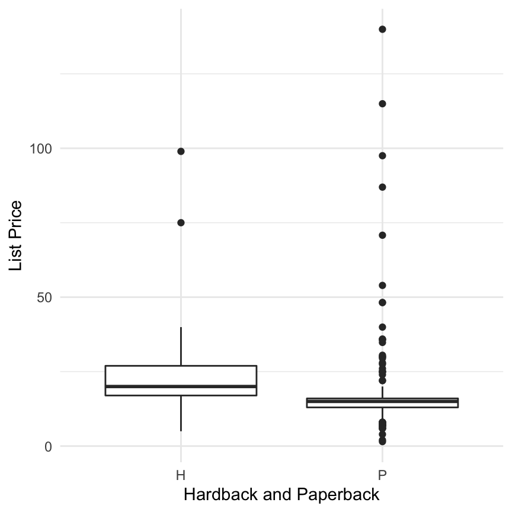

(a) Distribution of list price across all books, broken down by materials.

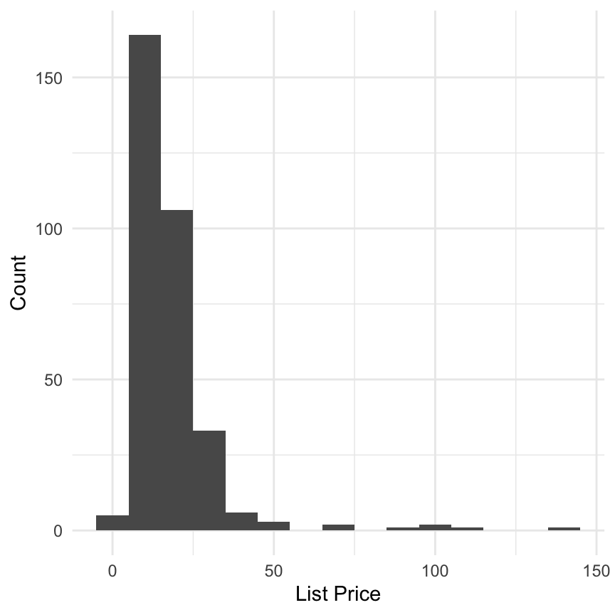

(b) Distribution of list price across all books.

Figure 1: Hardback or paperback books and list price

# Results

To quantify the relationship between list price of paperback books and that of hardback books, we fit a categorical regression model. In this model, the outcome variable was the list price, and the explanatory variable was hardback or paperback books. The predictions of this model are visualized in Figure 2, and the model’s coefficients are described in Table 2:

Table 2: Regression table describing the coefficients of the categorical regression model predicting list price for hardback and paperback books.

| term | estimate | std_error | statistic | p_value | lower_ci | upper_ci |
| --- | --- | --- | --- | --- | --- | --- |
| intercept | 22.394 | 1.492 | 15.005 | 0.000 | 19.458 | 25.330 |
| hard_paper: P | -5.259 | 1.752 | -3.001 | 0.003 | -8.706 | -1.811 |

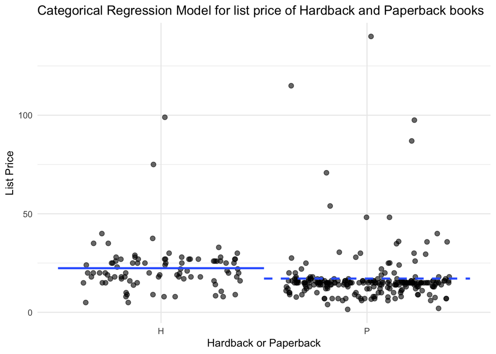

Figure 2: List price plotted against the hardback and paperback books, with the fitted regression line.

The fitted regression equation predicting list price from the hardback and paperback books are calculated below:

Table 3 summarizes the statistic of test statistic, p-value, alpha-level, and degree of freedom used for generating permutation test and t-test.

Table 3: Statistical summary of test statistic, p-value, alpha-level, and degrees of freedom for permutation test and t-test.

[output not shown]

# Discussion

## Conclusion

We found that there is a true difference between the average list price of hardback books and that of paperback books. Furthermore, the average list price of hardback books tends to be higher than the average list price of paperback books. In our data report, we sought to answer our question: Do hardback or paperback books affect the suggested list price from the publisher? If the reader’s goal is to have a wide range of collected books at a cheaper price, they are better off buying paperback books for cost affordability. In this report, our overall learning of pricing of hardback and paperback books on the Amazon market suggests that list pricing varies depending on the book’s materials (hard/paperback). Our interest in finding a cost effective method of purchasing on Amazon.com led us to learn that buying paperback books is cheaper than hardback books according to the list price suggested by the publisher.

## Limitation

The results could suggest that there could be variables that influence the list price of hardback and paperback books. Our report is limited because we only analyzed the relationship between list price and hard/paperback books. Although we did not have any data on the cost breakdown of paperback and hardback books, we could assume that time, materials, and labor impact the list price of books sold on Amazon.com. Publishers’ popularity can possibly influence the list price they assign their books. In addition, the difference between cult favorites and classic books versus newer and less popular books can influence the list pricing. Would cult favorite books be pricier or cheaper than niche books? How does demand for certain novels impact the list price on the Amazon website?

## Further Questions

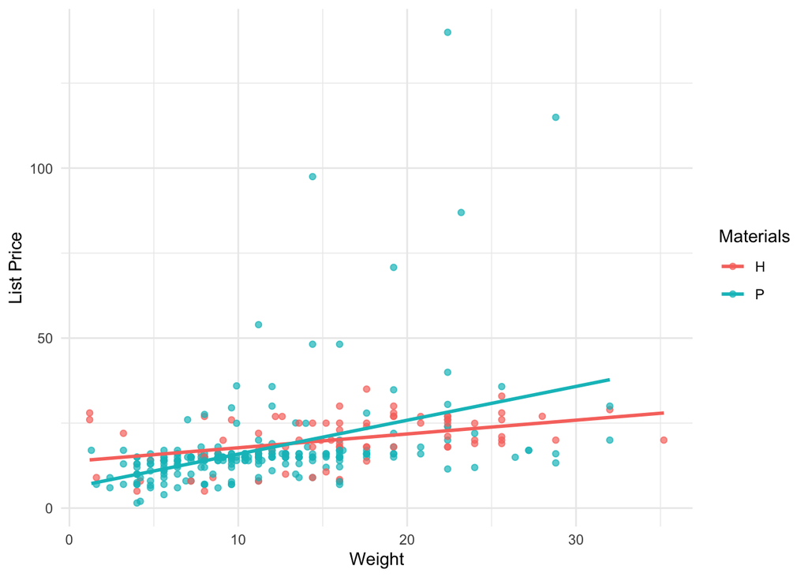

Figure 3: Weight plotted against list price, grouped by whether the books is hardback or paperback. The superimposed lines represent the predictions of a multiple regression model that allows for an interaction between weight and materials.

Further analysis of our data considered other variables and their possible impact on list pricing on hardback and paperback books. In the figure above, we created an exploratory analysis to observe if there is a relationship between the weight of the books and list price, with materials as the third variable. Our intention in creating this graph is to see to what extent the weight of books of different materials would have an effect on the list price of hardback and paperback books.

In Figure 3, we used a scatter plot between weight and list price, grouped by materials, fitted with multiple regression lines. Blue plot points represent paperback books, and red plot points represent hardback books. Both respective regression lines are colored in blue or red. We can observe that many of the blue plot points of paperback books tend to congregate in the lower left area of the graph, with a relatively centered low weight and low list price. Meanwhile, the red plot points of hardback books are more evenly distributed horizontally, meaning a greater variability of weight. We can see many outliers of paperback books having extremely high list prices with varying weights. However, despite their weight, most hardback books fall under a certain list price. The relationship between list price and weight appears to be slightly steeper for paperback books than hardback books, but it is difficult to say whether this difference in magnitude is large enough to be a significant difference between the two types of books.

##### References

“Amazon_books.” n.d. urlhttps://dasl.datadescription.com/datafile/amazon-books.

Birch, James. 2023. “Paperback Vs Hardcover: Which Is Better?” https://www.colourgraphics.com/blog/paperback-vs-hardcover-which-is-better/; Magento2 Store.

Blum, Dani. 2021. “Where Should You Buy Your Books?” *NY Times*, April.

# Appendix

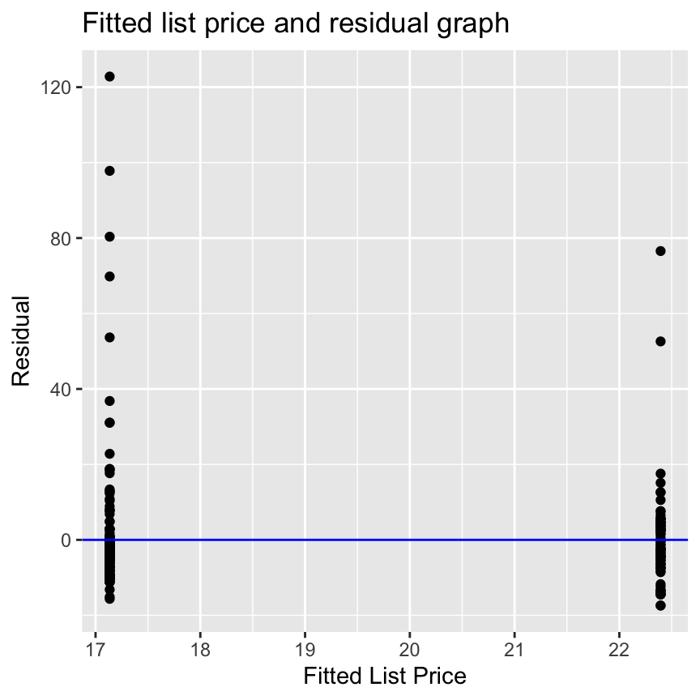

(a) Residual distribution of list price across all books, broken down by materials.

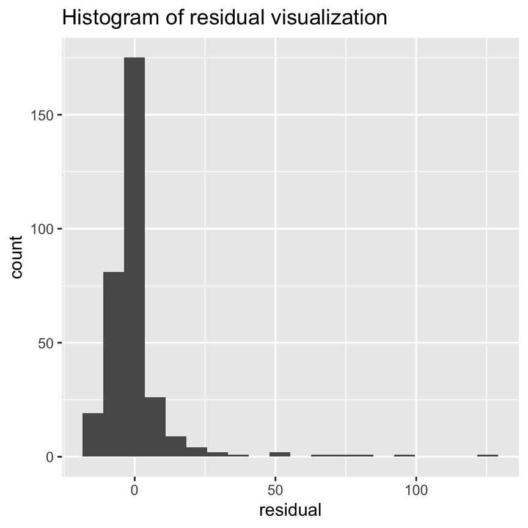

(b) Residual Distribution of list price across all books.

Figure 4: List price and residuals

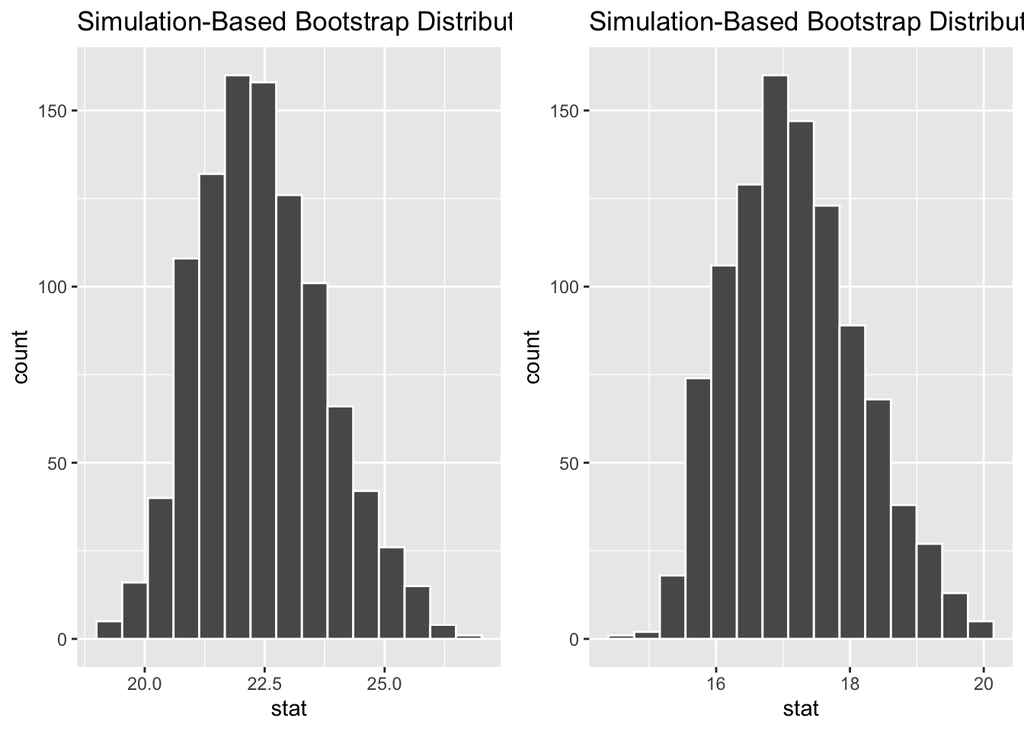

Figure 5: Distribution of average list price and hard/paperback books

Left panel in Figure 4 shows an indication that the equal variance assumption is violated due to the noticeable difference in the paperback and hardback point distribution range. Even though based on Figure 5, it seems like each material is normally distributed. However, the histogram of the residual errors of both materials shown in right panel in Figure 4 suggests that the assumption of normally distributed residuals is violated. Furthermore, there is no reason to suspect any dependence between the residual errors since there is nothing linking together the list price of paperback books to hardback books. Thus, we are confident in drawing inferences about whether there is a difference between the list price of hardback and that of paperback books based on the permutation method as a reasonable and reliable approach to the hypothesis test.

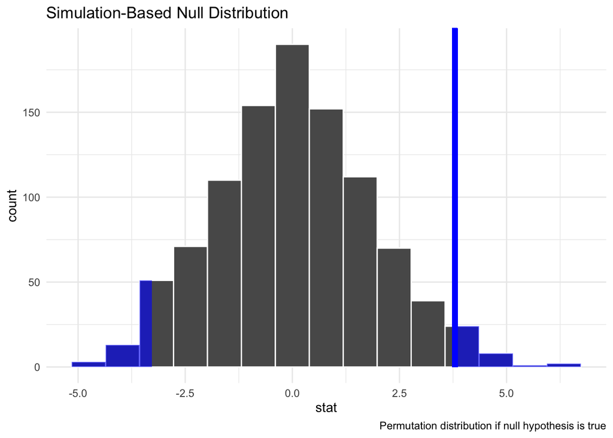

Null Distribution of list price and materials if null hypothesis is true in permutation test.